```python
import tensorflow as tf
from keras import layers, models, optimizers
```

# Breaking the curse of small datasets and Improving performance of ConvNets

### When developing Deep Learning models, one of the biggest challenges is collecting a large dataset. Thus, in this project, I used different Deep Learning techniques to improve performance of ConvNets when there is only a small number of data files are available.

'Dogs vs. Cats' dataset from Kaggle was used - https://www.kaggle.com/c/dogs-vs-cats/data

The training archive contains 25,000 images of dogs and cats.  
Dog pictures are labeled as 1 and cats are labeled as 0. (1 = dog, 0 = cat)

For this project's purpose, only a subset of this dataset was used.

```python
import os, shutil

original_dataset_dir = './cats_and_dogs/train'
base_dir = './cats_and_dogs_small'
os.mkdir(base_dir)

train_dir = os.path.join(base_dir, 'train')
os.mkdir(train_dir)

validation_dir = os.path.join(base_dir, 'validation')
os.mkdir(validation_dir)

test_dir = os.path.join(base_dir, 'test')
os.mkdir(test_dir)

train_cats_dir = os.path.join(train_dir, 'cats')
os.mkdir(train_cats_dir)
train_dogs_dir = os.path.join(train_dir, 'dogs')
os.mkdir(train_dogs_dir)

validation_cats_dir = os.path.join(validation_dir, 'cats')
os.mkdir(validation_cats_dir)
validation_dogs_dir = os.path.join(validation_dir, 'dogs')
os.mkdir(validation_dogs_dir)

test_cats_dir = os.path.join(test_dir, 'cats')
os.mkdir(test_cats_dir)
test_dogs_dir = os.path.join(test_dir, 'dogs')
os.mkdir(test_dogs_dir)

# first 1000 cat images are going to be used to train the model
fnames = ['cat.{}.jpg'.format(i) for i in range(1000)]
for fname in fnames:
    src = os.path.join(original_dataset_dir, fname)
    dst = os.path.join(train_cats_dir, fname)
    shutil.copyfile(src, dst)
# next 500 cat images are going to used for validation
fnames = ['cat.{}.jpg'.format(i) for i in range(1000, 1500)]
for fname in fnames:
    src = os.path.join(original_dataset_dir, fname)
    dst = os.path.join(validation_cats_dir, fname)
    shutil.copyfile(src, dst)
# next 500 cat images are going to used to test the model
fnames = ['cat.{}.jpg'.format(i) for i in range(1500, 2000)]
for fname in fnames:
    src = os.path.join(original_dataset_dir, fname)
    dst = os.path.join(test_cats_dir, fname)
    shutil.copyfile(src, dst)

# first 1000 dog images are going to be used to train the model
fnames = ['dog.{}.jpg'.format(i) for i in range(1000)]
for fname in fnames:
    src = os.path.join(original_dataset_dir, fname)
    dst = os.path.join(train_dogs_dir, fname)
    shutil.copyfile(src, dst)
# next 500 dog images are going to used for validation
fnames = ['dog.{}.jpg'.format(i) for i in range(1000, 1500)]
for fname in fnames:
    src = os.path.join(original_dataset_dir, fname)
    dst = os.path.join(validation_dogs_dir, fname)
    shutil.copyfile(src, dst)
# next 500 dog images are going to used to test the model
fnames = ['dog.{}.jpg'.format(i) for i in range(1500, 2000)]
for fname in fnames:
    src = os.path.join(original_dataset_dir, fname)
    dst = os.path.join(test_dogs_dir, fname)
    shutil.copyfile(src, dst)
```

```python
# double checking that the correct amount of pictures have been selected
print(len(os.listdir(train_cats_dir)))
print(len(os.listdir(validation_cats_dir)))
print(len(os.listdir(test_cats_dir)))

print(len(os.listdir(train_dogs_dir)))
print(len(os.listdir(validation_dogs_dir)))
print(len(os.listdir(test_dogs_dir)))
```

```
1000
500
500
1000
500
500
```

### Building a CNN model

```python
model = models.Sequential()
model.add(layers.Conv2D(32, (3,3), activation='relu', input_shape=(150,150,3)))
model.add(layers.MaxPooling2D((2,2)))
model.add(layers.Conv2D(64, (3,3), activation='relu'))
model.add(layers.MaxPooling2D((2,2)))
model.add(layers.Conv2D(128, (3,3), activation='relu'))
model.add(layers.MaxPooling2D((2,2)))
model.add(layers.Conv2D(128, (3,3), activation='relu'))
model.add(layers.MaxPooling2D((2,2)))
model.add(layers.Flatten())
model.add(layers.Dense(512, activation='relu'))
model.add(layers.Dense(1, activation='sigmoid'))

model.summary()
```

```
WARNING:tensorflow:From /Library/Frameworks/Python.framework/Versions/3.6/lib/python3.6/site-packages/tensorflow/python/framework/op_def_library.py:263: colocate_with (from tensorflow.python.framework.ops) is deprecated and will be removed in a future version.
Instructions for updating:
Colocations handled automatically by placer.
_________________________________________________________________
Layer (type)                 Output Shape              Param #
=================================================================
conv2d_1 (Conv2D)            (None, 148, 148, 32)      896
_________________________________________________________________
max_pooling2d_1 (MaxPooling2 (None, 74, 74, 32)        0
_________________________________________________________________
conv2d_2 (Conv2D)            (None, 72, 72, 64)        18496
_________________________________________________________________
max_pooling2d_2 (MaxPooling2 (None, 36, 36, 64)        0
_________________________________________________________________
conv2d_3 (Conv2D)            (None, 34, 34, 128)       73856
_________________________________________________________________
max_pooling2d_3 (MaxPooling2 (None, 17, 17, 128)       0
_________________________________________________________________
conv2d_4 (Conv2D)            (None, 15, 15, 128)       147584
_________________________________________________________________
max_pooling2d_4 (MaxPooling2 (None, 7, 7, 128)         0
_________________________________________________________________
flatten_1 (Flatten)          (None, 6272)              0
_________________________________________________________________
dense_1 (Dense)              (None, 512)               3211776
_________________________________________________________________
dense_2 (Dense)              (None, 1)                 513
=================================================================
Total params: 3,453,121
Trainable params: 3,453,121
Non-trainable params: 0
_________________________________________________________________
```

### RMSprop for optimizer

[figure not shown]

What **RMSprop** does is it keeps an exponentially weighted average of the squares of the derivatives.  
This helps damp out the oscillations and is a very effective optimizer

```python
model.compile(optimizer=optimizers.RMSprop(lr=1e-4), loss='binary_crossentropy', metrics=['acc'])
```

```python
from keras.preprocessing.image import ImageDataGenerator

train_datagen = ImageDataGenerator(rescale=1./255)
test_datagen = ImageDataGenerator(rescale=1./255)

train_generator = train_datagen.flow_from_directory(
train_dir, target_size=(150,150), batch_size=20, class_mode='binary')

validation_generator = test_datagen.flow_from_directory(
validation_dir, target_size=(150,150), batch_size=20, class_mode='binary')

history = model.fit_generator(train_generator, steps_per_epoch=2000//20, epochs=32,
                             validation_data=validation_generator, validation_steps=1000//20,
                             verbose=0)
model.save('cats_and_dogs_small_1.h5')
```

```
Found 2000 images belonging to 2 classes.
Found 1000 images belonging to 2 classes.
WARNING:tensorflow:From /Library/Frameworks/Python.framework/Versions/3.6/lib/python3.6/site-packages/tensorflow/python/ops/math_ops.py:3066: to_int32 (from tensorflow.python.ops.math_ops) is deprecated and will be removed in a future version.
Instructions for updating:
Use tf.cast instead.
```

### Training/ Validation accuracy

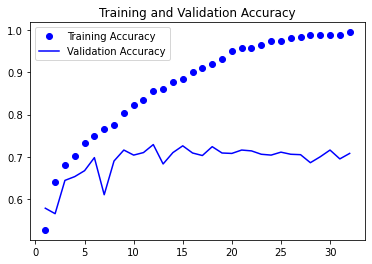

```python
import matplotlib.pyplot as plt

acc = history.history['acc']
val_acc = history.history['val_acc']
loss = history.history['loss']
val_loss = history.history['val_loss']

epochs = range(1, len(acc) + 1)

plt.plot(epochs, acc, 'bo', label='Training Accuracy')
plt.plot(epochs, val_acc, 'b', label='Validation Accuracy')
plt.title('Training and Validation Accuracy')
plt.legend()
plt.show()
```

### Training/ Validation loss

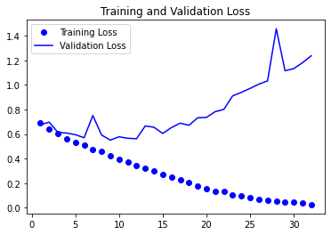

```python
plt.plot(epochs, loss, 'bo', label='Training Loss')
plt.plot(epochs, val_loss, 'b', label='Validation Loss')
plt.title('Training and Validation Loss')
plt.legend()
plt.show()
```

## → The graphs above show that this CNN model overfits and fails to perform well with validation dataset.

## What could be added to make the model perform better?

### Data augmentation

**Data augmentation** is used to increase the diversity of data available for training dataset, without actually collecting new data. Thus, this technique is useful to improve performance for models with smaller dataset.

```python
# Data Augmentation
datagen = ImageDataGenerator(rotation_range=20, width_shift_range=0.1, height_shift_range=0.1,
                            shear_range=0.1, zoom_range=0.1, horizontal_flip=True,
                            fill_mode='nearest')
# shear range for shearing transformation
```

### The code below shows an example for what images with Data Augmentation look like

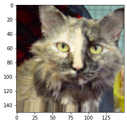

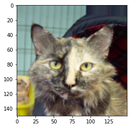

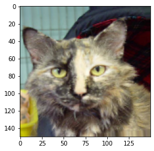

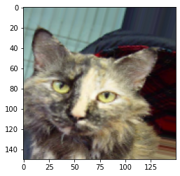

```python
from keras.preprocessing import image

fnames = sorted([os.path.join(train_cats_dir, fname) for fname in os.listdir(train_cats_dir)])

img_path = fnames[2] # an example
img = image.load_img(img_path, target_size=(150,150))

x = image.img_to_array(img) # convert it to numpy array -> (150, 150, 3)
x = x.reshape((1,) + x.shape) # (1, 150, 150, 3)

i = 0;
for batch in datagen.flow(x, batch_size=1):
    # print(batch.shape) (1, 150, 150, 3)
    plt.figure()
    imgplot = plt.imshow(image.array_to_img(batch[0]))
    i += 1
    if i == 4:
        break
```

### Add Data Augmentation and Dropout to a previous CNN model to improve performance

[figure not shown]

**Dropout** is a regularization method that reduces overfitting and improve the generalization of the model.  
During training, some number of layer outputs are randomly "dropped out". So, the model can learn "different path" to the "solution".

```python
model = models.Sequential()
model.add(layers.Conv2D(32, (3,3), activation='relu', input_shape=(150,150,3)))
model.add(layers.MaxPooling2D((2,2)))
model.add(layers.Conv2D(64, (3,3), activation='relu'))
model.add(layers.MaxPooling2D((2,2)))
model.add(layers.Conv2D(128, (3,3), activation='relu'))
model.add(layers.MaxPooling2D((2,2)))
model.add(layers.Conv2D(128, (3,3), activation='relu'))
model.add(layers.MaxPooling2D((2,2)))
model.add(layers.Flatten())
model.add(layers.Dropout(0.5)) # add droupout
model.add(layers.Dense(512, activation='relu'))
model.add(layers.Dense(1, activation='sigmoid'))

model.summary()
```

```
WARNING:tensorflow:From /Library/Frameworks/Python.framework/Versions/3.6/lib/python3.6/site-packages/keras/backend/tensorflow_backend.py:3445: calling dropout (from tensorflow.python.ops.nn_ops) with keep_prob is deprecated and will be removed in a future version.
Instructions for updating:
Please use `rate` instead of `keep_prob`. Rate should be set to `rate = 1 - keep_prob`.
_________________________________________________________________
Layer (type)                 Output Shape              Param #
=================================================================
conv2d_5 (Conv2D)            (None, 148, 148, 32)      896
_________________________________________________________________
max_pooling2d_5 (MaxPooling2 (None, 74, 74, 32)        0
_________________________________________________________________
conv2d_6 (Conv2D)            (None, 72, 72, 64)        18496
_________________________________________________________________
max_pooling2d_6 (MaxPooling2 (None, 36, 36, 64)        0
_________________________________________________________________
conv2d_7 (Conv2D)            (None, 34, 34, 128)       73856
_________________________________________________________________
max_pooling2d_7 (MaxPooling2 (None, 17, 17, 128)       0
_________________________________________________________________
conv2d_8 (Conv2D)            (None, 15, 15, 128)       147584
_________________________________________________________________
max_pooling2d_8 (MaxPooling2 (None, 7, 7, 128)         0
_________________________________________________________________
flatten_2 (Flatten)          (None, 6272)              0
_________________________________________________________________
dropout_1 (Dropout)          (None, 6272)              0
_________________________________________________________________
dense_3 (Dense)              (None, 512)               3211776
_________________________________________________________________
dense_4 (Dense)              (None, 1)                 513
=================================================================
Total params: 3,453,121
Trainable params: 3,453,121
Non-trainable params: 0
_________________________________________________________________
```

```python
model.compile(optimizer=optimizers.RMSprop(lr=1e-4), loss='binary_crossentropy', metrics=['acc'])
```

```python
train_datagen = ImageDataGenerator(rescale = 1./255, rotation_range=40,
                                   width_shift_range=0.2, height_shift_range=0.2,
                                   shear_range=0.2, zoom_range=0.2, horizontal_flip=True,
                                   fill_mode='nearest')
test_datagen = ImageDataGenerator(rescale = 1./255)

train_generator = train_datagen.flow_from_directory(
train_dir, target_size=(150,150), batch_size=20, class_mode='binary')

validation_generator = test_datagen.flow_from_directory(
validation_dir, target_size=(150,150), batch_size=20, class_mode='binary')

history = model.fit_generator(train_generator, steps_per_epoch=2000//20, epochs=32,
                             validation_data=validation_generator, validation_steps=1000//20,
                             verbose=0)
model.save('cats_and_dogs_small_2.h5')
```

```
Found 2000 images belonging to 2 classes.
Found 1000 images belonging to 2 classes.
```

### Training/ Validation accuracy after Data Augmentation & Dropout

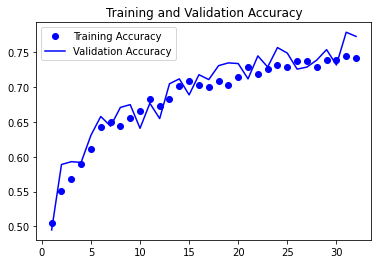

```python
import matplotlib.pyplot as plt

acc = history.history['acc']
val_acc = history.history['val_acc']
loss = history.history['loss']
val_loss = history.history['val_loss']

epochs = range(1, len(acc) + 1)

plt.plot(epochs, acc, 'bo', label='Training Accuracy')
plt.plot(epochs, val_acc, 'b', label='Validation Accuracy')
plt.title('Training and Validation Accuracy')
plt.legend()
plt.show()
```

### Training/ Validation loss after Data Augmentation & Dropout

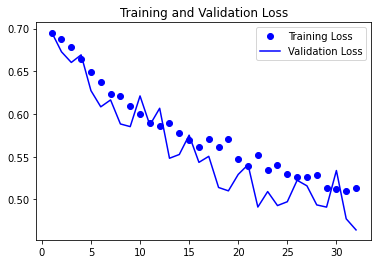

```python
plt.plot(epochs, loss, 'bo', label='Training Loss')
plt.plot(epochs, val_loss, 'b', label='Validation Loss')
plt.title('Training and Validation Loss')
plt.legend()
plt.show()
```

## What could be added to make the model perform better?

### Transfer Learning

Using **transfer learning** from a pre-trained network can be used to improve its accruacy.  
A **pre-trained model** is a saved network that was previously trained on a large dataset.  
For this project, we are going to use transfer learning to customize the pre-trained **ImageNet VGG16 model.**

```python
from keras.applications import VGG16
conv_base = VGG16(weights='imagenet', include_top=False, input_shape=(150,150,3))
# include_top is false because we want to classfiy only two classes (dog and cat)
# not all the classes that ImageNet has
conv_base.summary()
```

```
_________________________________________________________________
Layer (type)                 Output Shape              Param #
=================================================================
input_2 (InputLayer)         (None, 150, 150, 3)       0
_________________________________________________________________
block1_conv1 (Conv2D)        (None, 150, 150, 64)      1792
_________________________________________________________________
block1_conv2 (Conv2D)        (None, 150, 150, 64)      36928
_________________________________________________________________
block1_pool (MaxPooling2D)   (None, 75, 75, 64)        0
_________________________________________________________________
block2_conv1 (Conv2D)        (None, 75, 75, 128)       73856
_________________________________________________________________
block2_conv2 (Conv2D)        (None, 75, 75, 128)       147584
_________________________________________________________________
block2_pool (MaxPooling2D)   (None, 37, 37, 128)       0
_________________________________________________________________
block3_conv1 (Conv2D)        (None, 37, 37, 256)       295168
_________________________________________________________________
block3_conv2 (Conv2D)        (None, 37, 37, 256)       590080
_________________________________________________________________
block3_conv3 (Conv2D)        (None, 37, 37, 256)       590080
_________________________________________________________________
block3_pool (MaxPooling2D)   (None, 18, 18, 256)       0
_________________________________________________________________
block4_conv1 (Conv2D)        (None, 18, 18, 512)       1180160
_________________________________________________________________
block4_conv2 (Conv2D)        (None, 18, 18, 512)       2359808
_________________________________________________________________
block4_conv3 (Conv2D)        (None, 18, 18, 512)       2359808
_________________________________________________________________
block4_pool (MaxPooling2D)   (None, 9, 9, 512)         0
_________________________________________________________________
block5_conv1 (Conv2D)        (None, 9, 9, 512)         2359808
_________________________________________________________________
block5_conv2 (Conv2D)        (None, 9, 9, 512)         2359808
_________________________________________________________________
block5_conv3 (Conv2D)        (None, 9, 9, 512)         2359808
_________________________________________________________________
block5_pool (MaxPooling2D)   (None, 4, 4, 512)         0
=================================================================
Total params: 14,714,688
Trainable params: 14,714,688
Non-trainable params: 0
_________________________________________________________________
```

### Feature extraction

The way **feature extracion** works is that the pre-trained network is treated as an arbitary feature extractor, which allows the input image to propagate forward, stops at pre-specified layer, and takes the outputs of that layer as **features**.

```python
import numpy as np
batch_size = 20
datagen = ImageDataGenerator(rescale=1./255)

def extract_features(directory, sample_count):
    features = np.zeros(shape=(sample_count, 4, 4, 512))
    labels = np.zeros(shape=(sample_count))
    generator = datagen.flow_from_directory(directory, target_size=(150,150),
                                           batch_size=batch_size, class_mode='binary')
    i = 0
    for inputs_batch, labels_batch in generator:
        # print(inputs_batch.shape) (32, 150, 150, 3)
        # print(labels_batch.shape) (32, )

        # feature extraction using conv_base
        features_batch = conv_base.predict(inputs_batch)

        features[i * batch_size : (i + 1) * batch_size] = features_batch
        labels[i * batch_size : (i + 1) * batch_size] = labels_batch
        i += 1

        if i * batch_size >= sample_count:
            break;
    return features, labels
```

```python
train_features, train_labels = extract_features(train_dir, 2000)
validation_features, validation_labels = extract_features(validation_dir, 1000)
test_features, test_labels = extract_features(test_dir, 1000)
```

```
Found 2000 images belonging to 2 classes.
Found 1000 images belonging to 2 classes.
Found 1000 images belonging to 2 classes.
```

```python
# flatten features values for classification
train_features = np.reshape(train_features, (2000, 4*4*512))
validation_features = np.reshape(validation_features, (1000, 4*4*512))
test_features = np.reshape(test_features, (1000, 4*4*512))
```

### Train a simple, feedforward neural network on the top of the extracted features

There is no **data augmentation.**

```python
model = models.Sequential()
model.add(layers.Dense(256, activation='relu', input_dim=4*4*512))
model.add(layers.Dropout(0.5))
model.add(layers.Dense(1, activation='sigmoid'))

model.summary()
```

```
_________________________________________________________________
Layer (type)                 Output Shape              Param #
=================================================================
dense_5 (Dense)              (None, 256)               2097408
_________________________________________________________________
dropout_2 (Dropout)          (None, 256)               0
_________________________________________________________________
dense_6 (Dense)              (None, 1)                 257
=================================================================
Total params: 2,097,665
Trainable params: 2,097,665
Non-trainable params: 0
_________________________________________________________________
```

```python
model.compile(optimizer=optimizers.RMSprop(lr=2e-5), loss='binary_crossentropy', metrics=['acc'])

history = model.fit(train_features, train_labels, epochs=32,
                    batch_size=20, validation_data=(validation_features, validation_labels), verbose=0)
model.save('cats_and_dogs_small_3.h5')
```

### Training/ Validation accuracy after training NN on the top of the extracted features

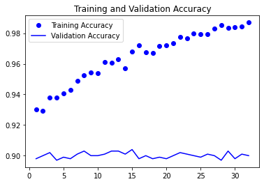

```python
acc = history.history['acc']
val_acc = history.history['val_acc']
loss = history.history['loss']
val_loss = history.history['val_loss']

epochs = range(1, len(acc) + 1)

plt.plot(epochs, acc, 'bo', label='Training Accuracy')
plt.plot(epochs, val_acc, 'b', label='Validation Accuracy')
plt.title('Training and Validation Accuracy')
plt.legend()
plt.show()
```

### Training/ Validation loss after training NN on the top of the extracted features

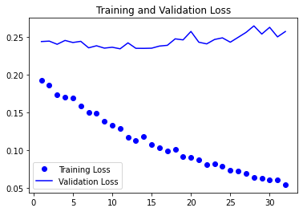

```python
plt.plot(epochs, loss, 'bo', label='Training Loss')
plt.plot(epochs, val_loss, 'b', label='Validation Loss')
plt.title('Training and Validation Loss')
plt.legend()
plt.show()
```

### Testing

```python
score = model.evaluate(test_features, test_labels)
print('Test Loss: ' + str(score[0]))
print('Test Accuracy: ' + str(score[1]))
```

```
Test Loss: 0.2711882150173187
Test Accuracy: 0.888
```

### → Using Transfer Learning and a simpler NN model on the top of the extracted features, the accuracy has improved significantly. However, even though Dropout was used, the model is overfitting. → Test result gives accuracy of 88%

## What could be used to make the model perform better?

### End-to-end learning

(Use this model **only on GPU)**

```python
model = models.Sequential()

model.add(conv_base)
model.add(layers.Flatten())
model.add(layers.Dense(256, activation='relu', input_dim=4*4*512))
model.add(layers.Dropout(0.5))
model.add(layers.Dense(1, activation='sigmoid'))

model.summary()
```

```
_________________________________________________________________
Layer (type)                 Output Shape              Param #
=================================================================
vgg16 (Model)                (None, 4, 4, 512)         14714688
_________________________________________________________________
flatten_3 (Flatten)          (None, 8192)              0
_________________________________________________________________
dense_7 (Dense)              (None, 256)               2097408
_________________________________________________________________
dropout_3 (Dropout)          (None, 256)               0
_________________________________________________________________
dense_8 (Dense)              (None, 1)                 257
=================================================================
Total params: 16,812,353
Trainable params: 16,812,353
Non-trainable params: 0
_________________________________________________________________
```

### Freezing layers

**Freezing layers** prevents its weights from being modified. This technique is often used in transfer learning, where the base model (trained on some other dataset) is frozen.

len(model.trainable_weights) = 4 means the model is only going to train 2 Dense layers, therefore, updating its weight and biasfor each layer.

```python
conv_base.trainable = False # freezing
len(model.trainable_weights)
```

```
4
```

```python
train_datagen = ImageDataGenerator(rescale = 1./255, rotation_range=20, width_shift_range=0.1,
                                             height_shift_range=0.1, shear_range=0.1,
                                             zoom_range=0.1, horizontal_flip=True, fill_mode='nearest')
test_datagen = ImageDataGenerator(rescale=1./255)

train_generator = train_datagen.flow_from_directory(train_dir,
                                                   target_size=(150,150), batch_size=20,
                                                   class_mode='binary')

validation_generator = test_datagen.flow_from_directory(validation_dir,
                                                       target_szie=(150,150),
                                                       batch_size=20,
                                                       class_mode='binary')
model.compile(optimizer=optimizers.RMSprop(lr=2e-5), loss='binary_crossentropy', metrics=['acc'])

history = model.fit_generator(train_generator, steps_per_epoch=2000//20, epochs=32,
                             validation_data=validation_generator,
                             validation_steps=1000//20,
                             verbose=0)
```

### Training/ Validation accuracy and loss after End-to-end learning

[figure not shown]

### → Despite the expensive computational cost of End-to-end learning, overfitting issue has been resolved in this network, compared to the previous one.

```python
test_generator = test_datagen.flow_from_directory(test_dir, target_size=(150,150),
                                                batch_size=20, class_mode='binary')

test_loss, test_acc = model.evaluate_generator(test_generator, steps=50)
print('Test Accuracy: ', test_acc)
```

Test Accuracy: 0.919

## → The accuracy has improved greatly even though the network only used a small dataset!

## What else could be added in Transfer Learning?

### Fine tuning

The base model has be "fronzen" so that it weights don't get modified.  
For **fine tuning**, we are going to "unfreeze" the last 3 layers of the base model, which are **block5_conv1, block5_conv2, block5_conv3**.

### Why is that only the last 3 layers are going to be fine-tuned?

```
- This is because earlier layers measure relatively simpler low level features like edges, wherease some later layers measure high level features.
- Transfer learning will make more sense if you suspect that low level features from the pre-trained model could be helpful for learning your task.
- Thus, it doesn't make sense to update weights from earlier layers of pre-trained model, which is why, for this case, only the last 3 layers are going to be trained and "fine-tuned".
- In this way, the model can be designed better to speicifically slove your particualr task.

- Additionally, if more than 3 layers were used for fine-tuning, there will be too many more parameters to train.
- Having too many parameters for small dataset can cause overfitting.
- Therefore, again, only the last few layers are going to be fine-tuned.
```

Since it is "fine-tuning", it is not desirable to significantly update weights in these layers - **block5_conv1, block5_conv2, block5_conv3** thus, the learning rate for RMSprop optimizer has changed to a lower value.

```python
conv_base.trainable = True
set_trainable = False

for layer in conv_base.layers:
    if layer.name == 'block5_conv1':
        set_trainable = True
    if set_trainable:
        layer.trainable = True
    else:
        layer.trainable = False
```

```python
model.compile(optimizer=optimizers.RMSprop(lr=le-5), loss='binary_crossentropy', metrics=['acc'])

history = model.fit_generator(train_generator, steps_per_epoch=2000//20, epochs=100,
                             validation_data=validation_generator,
                             validation_steps=1000//20,
                             verbose=0)
```

### Training/ Validation accuracy and loss after Fine Tuning

[figure not shown]

### Using Exponential Moving Average (EMA) to smoothen the curve

```python
def smooth_curve(points, factor=0.8):
    smoothed_points = []
    for point in points:
        if smooted_points:
            previous = smoothed_points[-1]
            smoothed_points.append(previous * factor + point * (1 - factor))
        else:
            smoothed_points.append(point)
    return smoothed_points
```

```python
acc = history.history['acc']
val_acc = history.history['val_acc']
loss = history.history['loss']
val_loss = history.history['val_loss']

epochs = range(1, len(acc) + 1)

plt.plot(epochs, smooth_curve(acc), 'bo', label='Training Accuracy')
plt.plot(epochs, smooth_curve(val_acc), 'b', label='Validation Accuracy')
plt.title('Training and Validation Accuracy')
plt.legend()
plt.show()

plt.plot(epochs, smooth_curve(loss), 'bo', label='Training Accuracy')
plt.plot(epochs, smooth_curve(val_loss), 'b', label='Validation Accuracy')
plt.title('Training and Validation Accuracy')
plt.legend()
plt.show()
```

### Training/ Validation accuracy and loss after smoothening the curves using EMA

[figure not shown]

### → Fine Tuning in this model led to overfitting which wasn't present in the pervious model. So, the model has become worse than before.

Fine tuning didn't improve the performance of the model. It is an optional last step that can potentially give the model incremental improvements.

# Conclusion

When dealing with **small datasets** for Deep Learning development, it could lead to **overfitting** and **failure in generalization of the model**.

In this project, I covered a few most commonly used techniques to tackle such issues of Deep Learning.  
**Data Augmentation, Transfer Learning, Feature Extraction, Fine Tuning** techniques can be used to "break the curse of small datasets", also **Dropout** regularization can prevent overfitting.

# Visualizing what ConvNets learn

```python
from keras.models import load_model
model = load_model('cats_and_dogs_small_2.h5')
model.summary()
```

```
_________________________________________________________________
Layer (type)                 Output Shape              Param #
=================================================================
conv2d_5 (Conv2D)            (None, 148, 148, 32)      896
_________________________________________________________________
max_pooling2d_5 (MaxPooling2 (None, 74, 74, 32)        0
_________________________________________________________________
conv2d_6 (Conv2D)            (None, 72, 72, 64)        18496
_________________________________________________________________
max_pooling2d_6 (MaxPooling2 (None, 36, 36, 64)        0
_________________________________________________________________
conv2d_7 (Conv2D)            (None, 34, 34, 128)       73856
_________________________________________________________________
max_pooling2d_7 (MaxPooling2 (None, 17, 17, 128)       0
_________________________________________________________________
conv2d_8 (Conv2D)            (None, 15, 15, 128)       147584
_________________________________________________________________
max_pooling2d_8 (MaxPooling2 (None, 7, 7, 128)         0
_________________________________________________________________
flatten_2 (Flatten)          (None, 6272)              0
_________________________________________________________________
dropout_1 (Dropout)          (None, 6272)              0
_________________________________________________________________
dense_3 (Dense)              (None, 512)               3211776
_________________________________________________________________
dense_4 (Dense)              (None, 1)                 513
=================================================================
Total params: 3,453,121
Trainable params: 3,453,121
Non-trainable params: 0
_________________________________________________________________
```

```
(1, 150, 150, 3)
```

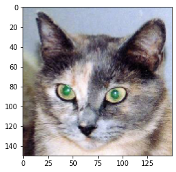

```python
img_path = os.path.join(test_cats_dir, 'cat.1700.jpg')
img = image.load_img(img_path, target_size=(150,150))
img_tensor = image.img_to_array(img)
img_tensor = np.expand_dims(img_tensor, axis=0) # changing the image to 4D tensor
# img_tensor = x.reshape((1,) + x.shape) this does the same job, changing the image to 4D tensor
# (1, 150, 150, 3)
img_tensor /= 255.

print(img_tensor.shape)
plt.imshow(img_tensor[0])
plt.show()
```

- conv2d_5
- max_pooling2d_5
- conv2d_6
- max_pooling2d_6
- conv2d_7
- max_pooling2d_7
- conv2d_8
- max_pooling2d_8

```python
layer_outputs = [layer.output for layer in model.layers[:8]]
print(model.input)
```

```
Tensor("conv2d_5_input_1:0", shape=(?, 150, 150, 3), dtype=float32)
```

### Building a model that returns 8 outputs using 'model.input'

```python
activation_model = models.Model(inputs=model.input, outputs=layer_outputs)
activations = activation_model.predict(img_tensor)
```

### Visualizing what 20th channel of the input looks like

```
(1, 148, 148, 32)
```

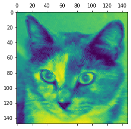

```python
first_layer_activation = activations[0]
print(first_layer_activation.shape)

plt.matshow(first_layer_activation[0,:,:,19], cmap='viridis')
```

### Visualizing what 16th channel of the input looks like

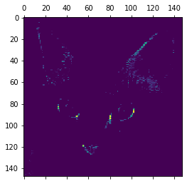

```python
plt.matshow(first_layer_activation[0,:,:,15], cmap='viridis')
```

```
Number of Channels: 32
Size: 148
```

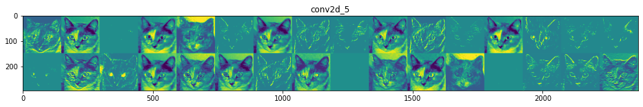

```
Number of Channels: 32
Size: 74
```

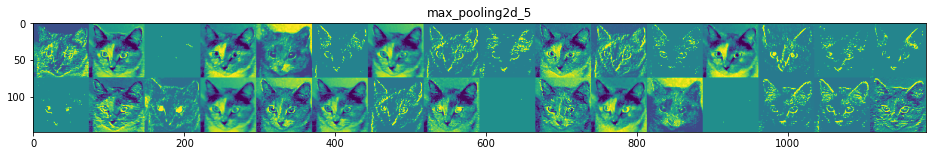

```
Number of Channels: 64
Size: 72
```

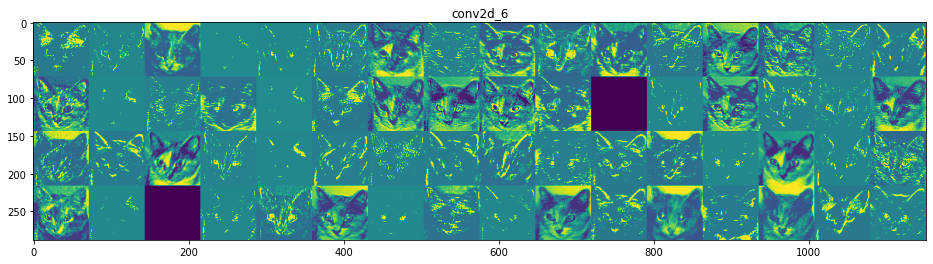

```
Number of Channels: 64
Size: 36
```

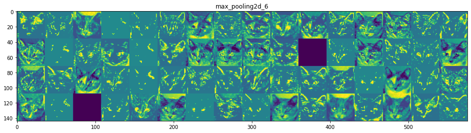

```
Number of Channels: 128
Size: 34
```

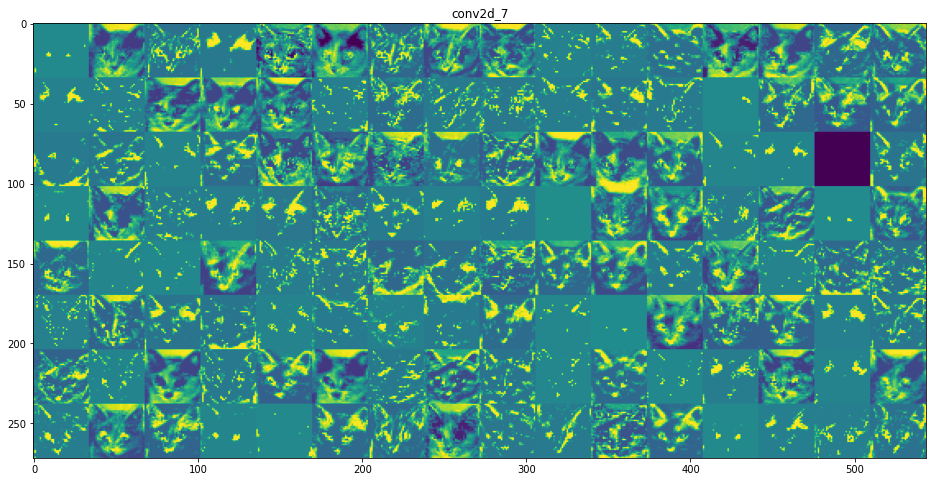

```
Number of Channels: 128
Size: 17
```

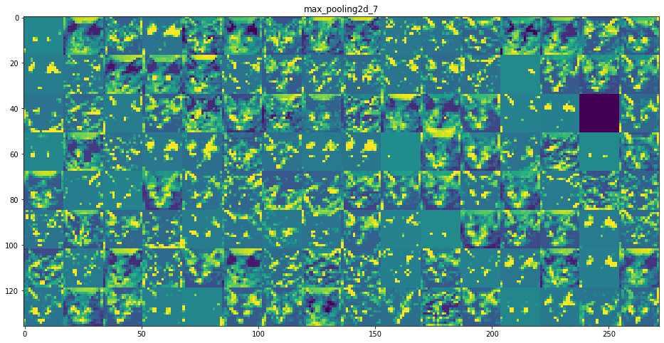

```
Number of Channels: 128
Size: 15
```

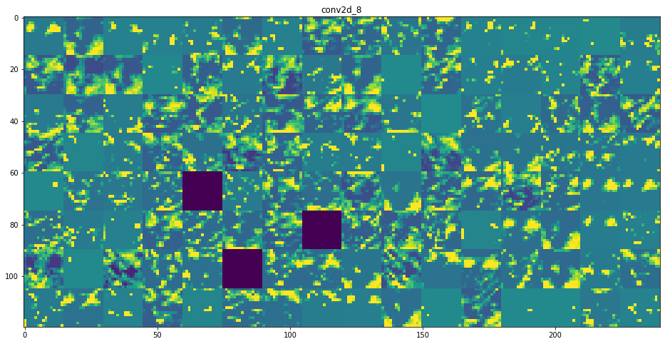

```
Number of Channels: 128
Size: 7
```

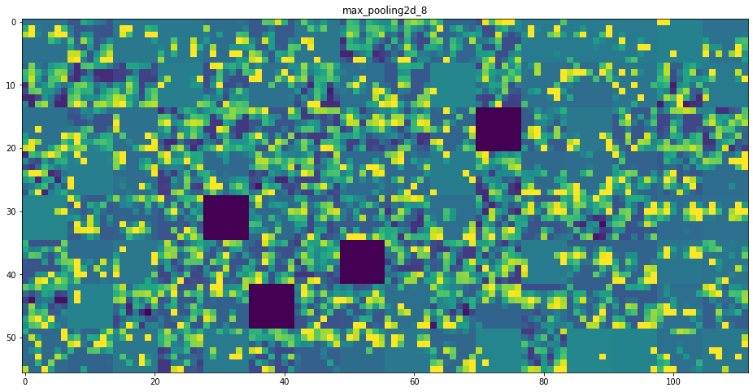

```python
layer_names = []
for layer in model.layers[:8]:
    layer_names.append(layer.name)

images_per_row = 16

for layer_name, layer_activation in zip(layer_names, activations):
    n_features = layer_activation.shape[-1]
    print("Number of Channels: " + str(n_features))

    size = layer_activation.shape[1]
    print("Size: " + str(size))

    n_cols = n_features // images_per_row
    display_grid = np.zeros((n_cols * size, images_per_row * size))

    for col in range(n_cols):
        for row in range(images_per_row):
            channel_image = layer_activation[0,:,:,
                                             col * images_per_row + row]
            channel_image -= channel_image.mean()
            channel_image /= channel_image.std()
            channel_image *= 64
            channel_image += 128
            channel_image = np.clip(channel_image, 0, 255).astype('uint8')

            display_grid[col * size : (col + 1) * size,
                        row * size : (row + 1) * size] = channel_image

        scale = 1. / size
    plt.figure(figsize=(scale * display_grid.shape[1],
                           scale * display_grid.shape[0]))
    plt.title(layer_name)
    plt.grid(False)
    plt.imshow(display_grid, aspect='auto', cmap='viridis')
    plt.show()
```

### Understanding what each layer in ConvNets do

The first few layers show various edge tections. Also, at that stage, the acivations are still retainig almost all of the information present in the image.

Then, the activations become increasingly abstract and less visually interpretable, which shows that the netwrok has filtered out irrelevant information. Later layers focus on the specific visual appearance (= more useful information for classfication) of the given image.

There are more **black feature maps** as the depth of the layer increases. This means that the pattern encoded by the filter was not present in the input image.

# Heatmap of Class Activation

```python
from keras import backend as K
from keras.applications.vgg16 import preprocess_input, decode_predictions

model = VGG16(weights='imagenet', input_shape=(224,224,3))
img = image.load_img(img_path, target_size=(224,224))
img_tensor = image.img_to_array(img)
print(img_tensor.shape)
img_tensor = img_tensor.reshape((1,) + img_tensor.shape)
print(img_tensor.shape)
img_tensor = preprocess_input(img_tensor)
preds = model.predict(img_tensor)
```

```
(224, 224, 3)
(1, 224, 224, 3)
```

```python
print('Predcited: ', decode_predictions(preds, top=3)[0])
```

```
Downloading data from https://s3.amazonaws.com/deep-learning-models/image-models/imagenet_class_index.json
Predcited:  [('n02124075', 'Egyptian_cat', 0.52406037), ('n02119789', 'kit_fox', 0.17562279), ('n02120505', 'grey_fox', 0.06227203)]
```

```python
np.argmax(preds[0])
```

```
285
```

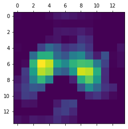

```python
egyptian_cat_output = model.output[:, 285]

last_conv_layer = model.get_layer('block5_conv3')
# block5_conv3 layer is the last layer of the VGG16

grads = K.gradients(egyptian_cat_output, last_conv_layer.output)[0]
# graident of 'egyptian_cat_output' with regard to the output feature map

pooled_grads = K.mean(grads, axis=(0, 1, 2))
iterate = K.function([model.input], [pooled_grads, last_conv_layer.output[0]])

pooled_grads_value, conv_layer_output_value = iterate([img_tensor])

for i in range(512):
    conv_layer_output_value[:, :, i] *= pooled_grads_value[i]
heatmap = np.mean(conv_layer_output_value, axis=-1)

heatmap = np.maximum(heatmap, 0)
heatmap /= np.max(heatmap)
plt.matshow(heatmap)
```

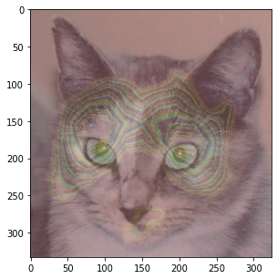

```python
import cv2
def deprocess_image(image):
    image -= image.mean()
    image /= (image.std() + 1e-5)
    image *= 0.1

    image += 0.5
    image = np.clip(image, 0, 1)

    # convert to RGB array
    image *= 255
    image = np.clip(image, 0, 255).astype('uint8')
    return image

img = cv2.imread(img_path)
heatmap = cv2.resize(heatmap, (img.shape[1], img.shape[0]))
heatmap = np.uint8(255 * heatmap)

heatmap = cv2.applyColorMap(heatmap, cv2.COLORMAP_JET)
superimposed_img = heatmap * 0.4 + img

plt.figure(figsize=(5, 5))
plt.imshow(deprocess_image(superimposed_img))
```

### What Heatmap visualization can answer:

- Why did the network think this image contained an Egyptian Cat?

[figure not shown]

The image on the left is Egyptian Cat and the image on the right is Kit Fox.